# Lab 9

Blue Team: Matt Lawson, Nick Zimmerman

3/14/2019

```r
trips <- read_csv("Nice_ride_trip_history_2017_season.csv", col_types=cols(
  "Start date"=col_datetime(format="%m/%d/%Y %H:%M"), "End date"=col_datetime(format="%m/%d/%Y %H:%M"), "Account type"=col_factor(levels=c("Member", "Casual"))
))

stations <- read_csv("Nice_ride_2017_Station_Locations.csv")
trips <- na.omit(trips)
```

### What docks make the most money and by who

```r
colnames(trips)[colnames(trips)=="Start station"] <- "station"
colnames(trips)[colnames(trips)=="Total duration (Seconds)"] <- "time"
colnames(trips)[colnames(trips)=="Account type"] <- "account"
teamdf <- trips %>% group_by(station) %>%  summarize(time = mean(time), count = n()) %>%
filter(time > 75000)
```

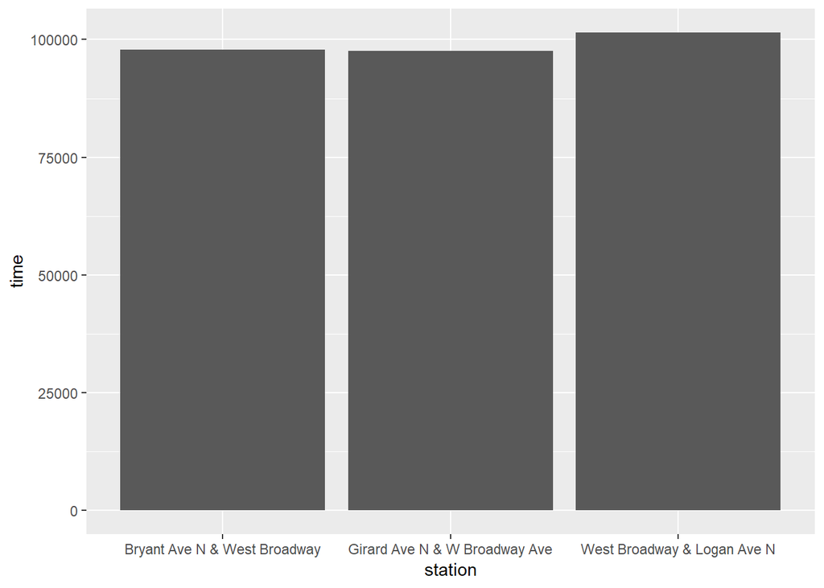

```r
ggplot(data = teamdf) + geom_bar(mapping = aes(x = station, y = time,), stat = "identity")
```

We also wanted to plot the membership on this graph but was not able to do it. But using Matt’s data we can conclude the three stations with the most run time and that Casuals spend 5 times more using the bikes therefore, casuals should be most of the income the company makes. Although we are not explicitly told how the money is made, if is based off were you docked is where you payed then looking at Brandon’s data you would see the top 5 stations with the most dockage.

### Matt

**Do members or casual riders ride for longer times?**

```r
colnames(trips)[colnames(trips)=="Total duration (Seconds)"] <- "time"
colnames(trips)[colnames(trips)=="Account type"] <- "account"

mattdf <- trips %>% group_by(account) %>% summarize(time = mean(time), count = n())
mattdf
```

| account | time | count |
| --- | --- | --- |
| Member | 911.390 | 290070 |
| Casual | 4596.983 | 170646 |

We can see here that casual users spends just over 5 times as long on average. However, members have riden nearly 2 times more than casual members have.

### Bing

What station has the longest ride times?

```r
  colnames(trips)[colnames(trips)=="Total duration (Seconds)"] <- "time"
  colnames(trips)[colnames(trips)=="station"] <- "sStation"

  eachStation <- trips %>% group_by(sStation) %>% summarize(time = mean(time))
  eachStation
```

| sStation | time |
| --- | --- |
| 100 Main Street SE | 1763.5953 |
| 10th Street & Nicollet Mall | 1895.1942 |
| 10th Street E & Cedar Street | 1725.3157 |
| 11th Ave S & S 2nd Street | 1523.2454 |
| 11th Street & Hennepin | 2305.4374 |
| 11th Street & Marquette | 2033.0768 |
| 15th Ave SE & 4th Street SE | 1007.7175 |
| 15th Ave SE & Como Ave SE | 1279.6208 |
| 18th Ave Trail & 2nd Street NE | 2977.3033 |
| 22nd Ave NE & California Street NE | 3299.1174 |

[output cut: 192 more lines]

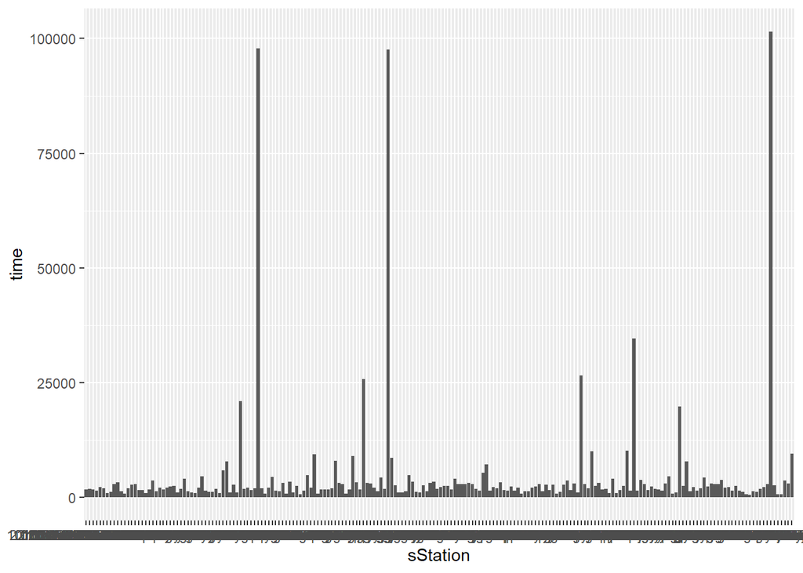

```r
  ggplot(data = eachStation) + geom_col(mapping = aes(x= sStation, y = time))
```

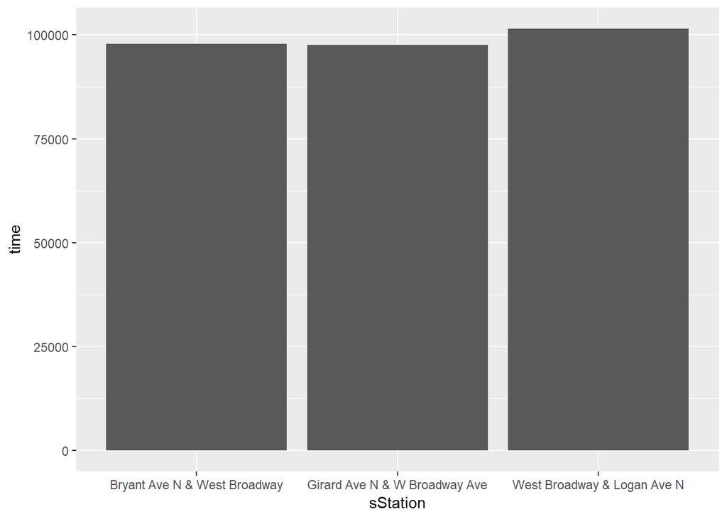

```r
  topStations <- eachStation %>% filter(time > 75000)

  ggplot(data = topStations) + geom_col(mapping = aes(x= sStation, y = time))
```

### Brandon

What Stations docks the most bikes

```r
colnames(stations)[colnames(stations)=="Name"] <- "name"
colnames(stations)[colnames(stations)=="Total docks"] <- "docks"

brandondf <- stations %>% group_by(name) %>%
summarize(docks = mean(docks), count = n()) %>%
filter(name == "Hennepin County Government Center" | name == "Lake Street & Knox Ave S" | name == "Coffman Union" | name == "Washington Ave SE & Union Street SE" | name == "100 Main Street SE")

arrange(brandondf, desc(docks))
```

| name | docks | count |
| --- | --- | --- |
| Hennepin County Government Center | 41 | 1 |
| Lake Street & Knox Ave S | 41 | 1 |
| Coffman Union | 35 | 1 |
| Washington Ave SE & Union Street SE | 31 | 1 |
| 100 Main Street SE | 27 | 1 |

This data shows the top five stations with the most docked bikes.

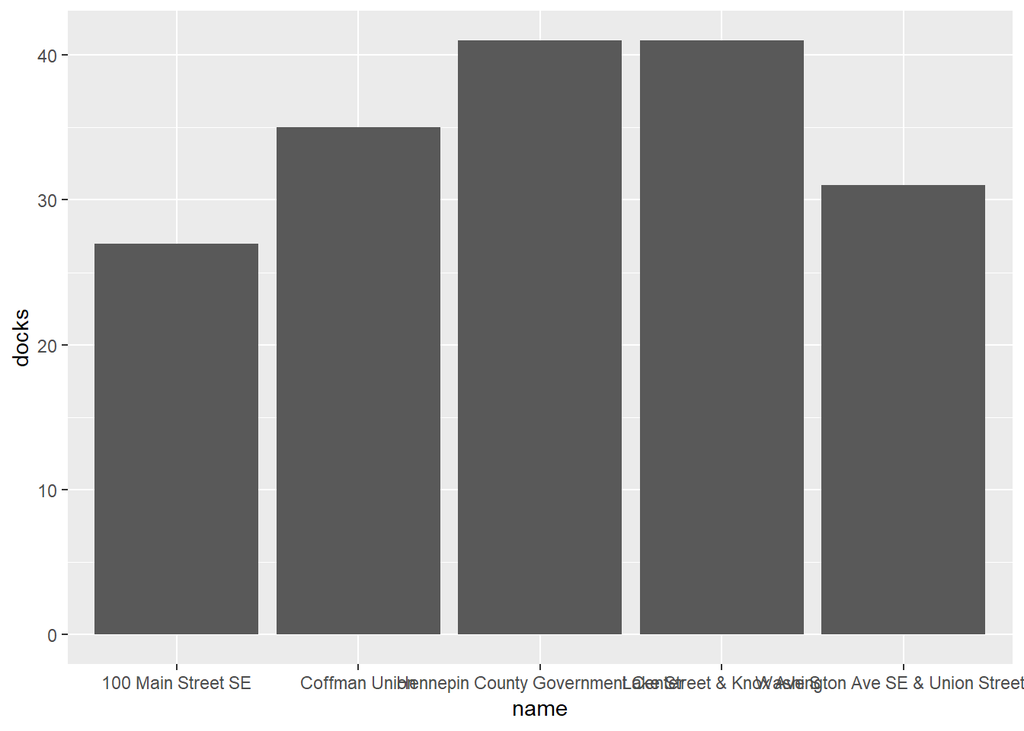

```r
ggplot(data = brandondf) + geom_bar(mapping = aes(x = name, y = docks), stat = "identity")
```

### Matt

Matt worked on his individual section. Matt transformed his coloumn names and then summarized them and displayed the membership versus casual

### Brandon

Brandon worked on his individual porition and the transformed formed his coloumns and also summarized the dock numbers in descending order in order to get the stations with the most docks.

### Bing

Bing worked on his individual porition and the team section. Transformed formed his coloumns and also summarized the ride time with the docks with the most ride time.

### Nick

Nick worke don his indivdual portion. Transformed his data by using mutate and a for loop. Nick could not get his code to work